# Statistics

- "... a branch of mathematics dealing with the collection, analysis, interpretation, presentation and organization of data." (Wikipedia)
- models the real world into mathematical objects (lines, curves, etc.)
- reason new knowledge from existing evidence (inference) and state how confident we are about that reasoning (probability)
- **Descriptive Statistics**: Summarizing information of a population
- **Inferential Statistics**: Predict behavior of population based on a sample. Uses probability to find out the confidence of the predictions

# Descriptive Statistics - univariate

## 1. Measures of central tendency

- **Mean**: average, sum of observations divided by number of observations
- **Median**: observation that falls in the middle of ordered sample, splits sample into 2 when ordered.
- **Mode**: most frequent value

## 3. Measures of variability (variation, spread)

- **Range**: difference between largest and smallest observation
- **Standard Deviation**: deviation of data from measure of center; typical distance of an observation from the mean
- **Variance**: another measure of how far observations are spread out from their mean value, calculated as square of standard deviation

## Standard Deviation & Variance - a measure of variability

[figure not shown]

```
count    4631.000000
mean       40.464452
std        18.566377
min         0.000000
25%        25.220761
50%        38.541804
75%        53.658537
max       100.000000
Name: Joe Biden %, dtype: float64
```

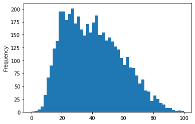

```python
import pandas as pd
df = pd.read_csv("data/us_election_2020_processed")
df = df['Joe Biden %']
df.plot.hist(bins=50)
df.describe()
```

# Population & Sample

- **Population**: total set of subjects of interest in a study
- **Sample**: subset of population on which data is collected

# Random Variable

- variable whose values depend on the outcomes of a random experiment

$\neq$ variable in algebra, where the value can be calculated and every time you calculate it, you will get the same result

## Representative samples

- Is the sample representative?
- What is the probability that the sample is equal to the population
- If x% of a sample of people have Y, it does **NOT** automatically mean that x% of people have Y

[figure not shown]

- A sample is representative if the variation is the same in the sample as in the population
- How do you measure variation?
  - Mean
  - Deviation from mean

# Population & Sampling Exercise

## Standard Deviation - a measure of variability

- The **deviation** of an observation $y_{i}$ from the sample mean $\bar{y}$ is $(y_{i} - \bar{y})$, the difference between them.
- The **standard deviation** $s$ of $n$ observations is:

$$s = \sqrt{\frac{\sum (y_{i} - \bar{y})^{2}}{n-1}}$$

- $y_{i}$ = value of an observation
- $\bar{y}$ = sample mean

### Probability Distribution

- **Probability distribution**: shows possible outcomes/values a variable can have and their probabilities

## Central Limit Theorem and Normal distribution

[figure not shown]

## Further Resources:

- https://learn.datacamp.com/courses/statistical-thinking-in-python-part-1